# Travail pratique 3

Question 1 - Persistance des données

Équipe 13

Loïc Artino (536 756 361)

François L’Écuyer (901 346 493)

11 décembre 2020

# Question 1.1 - Base de données intègre: ménage pour rendre le tout intègre

Il y a trois étapes préalables à la création de la base de données :

- La création des tables à partir des fichiers importées ;
- La vérification de la cohérence et de l’intégrité d’entité de chaque table ;
- La vérification de l’intégrité référentielle entre les tables.

## Importation des données

La première étape consiste à créer les tables à partir de fichiers importés de format CSV.

```r
# Importation des données

data_cat = read_csv("data/Q1_categories.csv")
data_com = read_csv("data/Q1_companies.csv")
data_loc = read_csv("data/Q1_locations.csv")
data_typ = read_csv("data/Q1_types.csv")
```

Suite à ces opérations, on peut voir les premiers enregistrements des quatre tables qui ont été créées dans les Tableaux 1 à 4.

**Tableau 1 - Liste partielle des catégories de compagnies**

| category |
| --- |
| Insurance |
| Energy |
| Data/Technology |
| Aerospace and Defense |
| Transportation |

**Tableau 2 - Liste partielle des compagnies**

| name | url | year_founded | city | state | full_time_employees | type | company_category | revenue_source | business_model |
| --- | --- | --- | --- | --- | --- | --- | --- | --- | --- |
| Weather Decision Technologies | http://www.wdtinc.com/ | 1999 | Norman | OK | 51-200 | Private | Environment & Weather | Not reported by company | Business to Business |
| Import.io | http://import.io | 2012 | San Francisco | CA | 11-50 | Private | Data/Technology | Database licensing, sell data sets | Business to Business, Business to Consumer |
| The Govtech Fund | www.govtechfund.com | 2014 | San Francisco | CA | NA | Private | Finance & Investment | Not reported by company | NA |
| StreetCred Software, Inc | streetcredsoftware.com | 2012 | Southlake | TX | 11-50 | Private | Governance | Software licensing, Subscriptions | Business to Government |
| Biovia | http://accelrys.com | 2001 | San Diego | CA | NA | Public | Scientific Research | Not reported by company | Business to Business |

**Tableau 3 - Liste partielle des localisations des compagnies**

| city | state |
| --- | --- |
| Melbourne | FL |
| San Jose | CA |
| Branchburg | NJ |
| Milford | CT |
| Brentwood | TN |

**Tableau 4 - Liste partielle des types de compagnies**

| type | description |
| --- | --- |
| Public | publicly traded company |
| Private | A privately held company, private company, or close corporation |
| Private | Privately held company |
| Nonprofit | non-business entity, not-for-profit organization, or nonprofit institution |

La deuxième étape consiste à vérifier la cohérence et l’intégrité d’entité de chaque table en s’assurant que chaque table contient des données de qualité et une clé primaire unique.

## Cohérence et intégrité d’entité de la table data_cat

La vérification de la cohérence se fait de façon visuelle en vérifiant si certaines données n’ont pas été créées de façon inconstante. Cela a permis de constater qu’il existait des enregistrements qui étaient effectivement problématiques. Le premier enregistrement problématique est **Business & Legal Services** qui ressemble énormément à l’enregistrement **Business and Legal Services**. Il est évident qu’on parle ici de la même chose donc nous allons supprimer l’enregistrement **Business and Legal Services**. Par ailleurs, les enregistrements **Environment** et **Weather** sont représentés de façon individuelle alors qu’il existe un champ **Environment & Weather**. Nous allons donc inclure les enregistrements **Environment** et **Weather** dans l’enregistrement **Environment and Weather** même si cette décision revient souvent à la personne qui utilisera la base de données selon la forme des données qu’elle désire extraire de la base de données. Il est important de noter que puisque le champ **category** de la table **data_cat** est la clé étrangère de la table **data_com**, il va falloir faire ces mêmes transformations dans la table **data_com** lorsque nous vérifierons l’intégrité référentielle de la base de données.

```r
# Changement des enregistrements qui ressemblent à un autre enregistrement

data_cat$category[data_cat$category == "Business and Legal Services"] <- "Business & Legal Services"
data_cat$category[data_cat$category == "Environment"] <- "Environment & Weather"
data_cat$category[data_cat$category == "Weather"] <- "Environment & Weather"
```

Puisque la table **data_cat** est constituée d’un seul champ, implicitement ce champ sera la clé unique si chaque élément est différent des autres. Il est évident que suite aux transformations précédentes, il y aura des enregistrements en doublons. Pour régler ce problème, nous procéderons directement à la suppression des doublons avec la fonction **duplicated** puis nous vérifierons qu’il ne subsiste pas de doublons dans la table. De plus, nous allons supprimer les éléments manquants **NA** du champ **category** puisqu’il s’agit d’une clé primaire.

```r
# Suppression des doublons de la table data_cat

data_cat <- data_cat[!duplicated(data_cat),]

# Vérification de l'unicité des éléments de la clé primaire de la table data_cat

data_cat %>%
  count(category) %>%
  filter(n > 1) %>%
  nrow()

# Suppression des éléments manquants (NA)

data_cat <- na.omit(data_cat)
```

Suite à ces opérations, on peut constater qu’il subsiste **0** doublon(s) dans le champ **category** de la table **data_cat** ainsi que **0** valeur(s) manquante(s). Ensuite, nous devons vérifier si le type du champ **category** est bien celui attendu.

```r
# Vérification du type des colonnes de la table data_cat

data_cat %>% map(typeof)
```

La vérification du type du champ **category**, nous permet de constater qu’il est de type **character**, ce qui est conforme à ce qui est attendu. Suite à ces opérations, on peut les éléments de la table **data_cat** dans le Tableau 5.

**Tableau 5 - Table data_cat**

| category |
| --- |
| Insurance |
| Energy |
| Data/Technology |
| Aerospace and Defense |
| Transportation |
| Environment & Weather |
| Lifestyle & Consumer |
| Research & Consulting |
| Finance & Investment |
| Media |
| Business & Legal Services |
| Scientific Research |
| Food & Agriculture |
| Education |
| Governance |
| Healthcare |
| Geospatial/Mapping |
| Housing/Real Estate |

## Cohérence et intégrité d’entité de la table data_typ

Les mêmes étapes de vérification de la cohérence que la table **data_cat** ont été suivies pour la table **data_typ** i.e une vérification visuelle de la table, la suppression des doublons et la vérification du type des champs. Cependant, la fonction **distinct** a été utilisée dans ce cas parce que les données du champs **description** différaient avec la même clé primaire.

```r
# Suppression des doublons de la table data_typ

data_typ <- distinct(data_typ,type, .keep_all= TRUE)

# Vérification de l'unicité des éléments de la clé primaire de la table data_typ

data_typ %>%
  count(type) %>%
  filter(n > 1) %>%
  nrow()

# Vérification du type des colonnes de la table data_typ

data_typ %>% map(typeof)
```

Suite à ces opérations, on peut constater qu’il subsiste **0** doublon(s) dans le champ **type** de la table **data_typ**. La vérification du type des champs **type** et **description**, nous permet aussi de constater qu’ils sont de type **character, character**, ce qui est conforme à ce qui est attendu pour ces champs. On peut voir les éléments de la table **data_typ** dans le Tableau 6.

**Tableau 6 - Table data_typ**

| type | description |
| --- | --- |
| Public | publicly traded company |
| Private | A privately held company, private company, or close corporation |
| Nonprofit | non-business entity, not-for-profit organization, or nonprofit institution |

## Cohérence et intégrité d’entité de la table data_loc

Ici aussi, les mêmes étapes de vérification de la cohérence que les tables précédentes ont été suivies pour la table **data_loc** i.e une vérification visuelle de la table, la suppression des doublons et la vérification du type des champs. De plus, un champ numérique séquentiel a été créé pour servir de clé primaire.

```r
# Changement des enregistrements qui ressemblent à un autre enregistrement

data_loc$city[data_loc$city == "Berkely"] <- "Berkeley"
data_loc$city[data_loc$city == "Boston, MA"] <- "Boston"
data_loc$city[data_loc$city == "Denver, CO"] <- "Denver"
data_loc$city[data_loc$city == "St Louis"] <- "St. Louis"
data_loc$city[data_loc$city == "Washington DC"] <- "Washington"
data_loc$city[data_loc$city == "Log Angeles"] <- "Los Angeles"

# Suppression des doublons de la table data_loc

data_loc <- data_loc[!duplicated(data_loc),]

# Ajout de la colonne de la clé primaire numérique

data_loc <-
  data_loc %>%
  mutate(location_id = row_number())

# Vérification de l'unicité des éléments de la clé primaire de la table data_loc

data_loc %>%
  count(location_id) %>%
  filter(n > 1) %>%
  nrow()

# Vérification du type des colonnes de la table data_loc

data_loc %>% map(typeof)
```

**Tableau 7 - Table data_loc**

| city | state | location_id |
| --- | --- | --- |
| Melbourne | FL | 1 |
| San Jose | CA | 2 |
| Branchburg | NJ | 3 |
| Milford | CT | 4 |
| Brentwood | TN | 5 |

## Cohérence et intégrité d’entité de la table data_com

La table **data_com** est plus complexe et il faut faire attention à ce que nous faisons dans la transformation des champs car plusieurs constituent des clés étrangères à relier avec d’autres tables. Comme pour les autres tables, la première étape a constitué à vérifier visuellement si certains enregistrements n’avaient pas été remplis de façon constante. ensuite, nous avons créé une clé primaire numérique qui n’existait pas actuellement dans la table pour finalement vérifier les types des champs.

```r
# Changement des enregistrements qui ressemblent à un autre enregistrement

data_com$city[data_com$city == "Berkely"] <- "Berkeley"
data_com$city[data_com$city == "Boston, MA"] <- "Boston"
data_com$city[data_com$city == "Denver, CO"] <- "Denver"
data_com$city[data_com$city == "St Louis"] <- "St. Louis"
data_com$city[data_com$city == "Washington DC"] <- "Washington"
data_com$city[data_com$city == "Washington, D.C."] <- "Washington"
data_com$city[data_com$city == "New York City"] <- "New York"
data_com$city[data_com$city == "Log Angeles"] <- "Los Angeles"
data_com$type[data_com$type == "partnership"] <- "Partnership"

# Ajout de la colonne de la clé primaire numérique

data_com <-
  data_com %>%
  mutate(id = row_number())

# Vérification de l'unicité des éléments de la clé primaire de la table data_loc

data_com %>%
  count(id) %>%
  filter(n > 1) %>%
  nrow()

# Vérification du type des colonnes de la table data_loc

data_com %>% map(typeof)
```

Suite à ces opérations, on constate qu’il subsiste **0** doublon(s) dans le champ **id** qui constitue la clé primaire. La vérification du type des champs, nous permet de constater que les types sont **character, character, double, character, character, character, character, character, character, character, integer**. Dans ce cas, nous devons modifier le format du champ **year_founded** du type **double** à **integer**.

```r
# Modification du type du champ year_founded

data_com <-
data_com %>%
mutate(year_founded = as.integer(year_founded))

# Vérification de l'unicité des éléments de la clé primaire de la table data_loc

data_com %>%
  count(id) %>%
  filter(n > 1) %>%
  nrow()
```

**Tableau 8 - Table data_com**

| name | url | year_founded | city | state | full_time_employees | type | company_category | revenue_source | business_model | id |
| --- | --- | --- | --- | --- | --- | --- | --- | --- | --- | --- |
| Weather Decision Technologies | http://www.wdtinc.com/ | 1999 | Norman | OK | 51-200 | Private | Environment & Weather | Not reported by company | Business to Business | 1 |
| Import.io | http://import.io | 2012 | San Francisco | CA | 11-50 | Private | Data/Technology | Database licensing, sell data sets | Business to Business, Business to Consumer | 2 |
| The Govtech Fund | www.govtechfund.com | 2014 | San Francisco | CA | NA | Private | Finance & Investment | Not reported by company | NA | 3 |
| StreetCred Software, Inc | streetcredsoftware.com | 2012 | Southlake | TX | 11-50 | Private | Governance | Software licensing, Subscriptions | Business to Government | 4 |
| Biovia | http://accelrys.com | 2001 | San Diego | CA | NA | Public | Scientific Research | Not reported by company | Business to Business | 5 |

## Intégrité référentielle de la base de données

La troisième étape avant de créer la base de données est de s’assurer s’assurer que l’intégrité référentielle est respectée entre toutes les tables au travers les clés primaires et étrangères. Dans le cas présent, il y a trois clés étrangères à vérifier dans la table **data_com** provenant des tables **data_cat**, **data_loc** et **data_typ**.

### *Vérification de l’intégrité référentielle entre les tables data_com et data_cat*

Pour vérifier que l’intégrité référentielle est respectée entre les tables **data_com** et **data_cat**, il faut s’assurer que toute les données de la clés étrangères de la table **data_com** soient présentes dans la table **data_cat**.

```r
# Vérification des données manquantes dans la table data_cat

data_com %>%
  anti_join(data_cat, by = c('company_category' = 'category')) %>%
select(company_category) %>%
distinct()
```

Suite à cette vérification, on peut constater que le seul enregistrement manquant est NA, ce qui est correct puisqu’il est possible que certains enregistrements de la table **data_com** ne contiennent pas d’information quant à la catégorie de client. On peut conclure que l’intégrité référentielle est respectée entre les tables **data_com** et **data_cat** et voir les éléments de la table **data_cat** dans le Tableau 9.

**Tableau 9 - Table data_cat**

| category |
| --- |
| Insurance |
| Energy |
| Data/Technology |
| Aerospace and Defense |
| Transportation |
| Environment & Weather |
| Lifestyle & Consumer |
| Research & Consulting |
| Finance & Investment |
| Media |
| Business & Legal Services |
| Scientific Research |
| Food & Agriculture |
| Education |
| Governance |
| Healthcare |
| Geospatial/Mapping |
| Housing/Real Estate |

### *Vérification de l’intégrité référentielle entre les tables data_com et data_typ*

```r
# Vérification des données manquantes dans la table data_typ

data_com %>%
  anti_join(data_typ, by = c('type' = 'type')) %>%
select(type) %>%
distinct()
```

- Partnership
- Public (Federal-USGS)
- nonprofit + commercial spinoff
- sole proprietorship
- Permitting Assistance

```r
# Ajout des valeurs manquantes

values_to_add <-
  data_com %>%
  anti_join(data_typ, by = c('type' = 'type')) %>%
  select(type) %>%
  distinct()
values_to_add <-
  values_to_add %>%
  rename(type = type)
data_typ <-
  data_typ %>%
  bind_rows(values_to_add)

# Suppression de la valeur NA

 data_typ = data_typ[-c(4),]

# Vérification des données manquantes dans la table data_typ

data_com %>%
  anti_join(data_typ, by = c('type' = 'type')) %>%
select(type) %>%
distinct()
```

Suite à ces opérations, on constate que la table **data_typ** contient huit enregistrements différentes qui sont toutes présentes dans la table **data_com** pour respecter l’intégrité référentielle. On peut voir les éléments de la table **data_typ** au tableau 10.

**Tableau 10 - Table data_typ**

| type | description |
| --- | --- |
| Public | publicly traded company |
| Private | A privately held company, private company, or close corporation |
| Nonprofit | non-business entity, not-for-profit organization, or nonprofit institution |
| Partnership | NA |
| Public (Federal-USGS) | NA |
| nonprofit + commercial spinoff | NA |
| sole proprietorship | NA |
| Permitting Assistance | NA |

### *Vérification de l’intégrité référentielle entre les tables data_com et data_loc*

Pour respecter l’intégrité référentielle entre la table **data_com** et la table **data_loc**, il faut arranger les champs **city** et **state** de la table **data_com** dans un nouveau champ nommé **location_id** qui servira de clé étrangère vers la clé primaire de la table **data_loc** puis vérifier que tous les champs de la table **data_loc** sont présents dans la table **data_com**.

```r
# Vérification des données manquantes dans la table data_loc

data_com %>%
  anti_join(data_loc, by = c('city' = 'city',
                             'state' = 'state')) %>%
  select(city, state) %>%
  distinct()

# Ajout des valeurs manquantes

values_to_add_2 <-
  data_com %>%
  anti_join(data_loc, by = c('city' = 'city',
                             'state' = 'state')) %>%
  select(city, state) %>%
  distinct()
values_to_add_2 <-
  values_to_add_2 %>%
  rename(city = city)
data_loc <-
  data_loc %>%
  bind_rows(values_to_add_2)

# Actualisation de location_id

  data_loc <- data_loc %>%
    mutate(location_id = row_number())

# Création du champ location_id dans la table data_com

  data_com <- data_com %>%
    left_join(data_loc, by = c('city' = 'city',
                               'state' = 'state'))

# Suppression des colonnes city et state dans la table data_com

  data_com <- data_com %>%
    select(-city, -state)
```

Suite à ces opérations, on constate que plusieurs enregistrements ont été créées dans la table **data_loc** particulièrement ceux dont seul l’état étaient présent table **data_com**. On peut voir, les cinq premiers éléments de la table **data_loc** au Tableau 11.

**Tableau 11 - Table data_loc**

| city | state | location_id |
| --- | --- | --- |
| Melbourne | FL | 1 |
| San Jose | CA | 2 |
| Branchburg | NJ | 3 |
| Milford | CT | 4 |
| Brentwood | TN | 5 |

# Question 1.2 - Base de données: création de la base de données

Après s’est assuré de la qualité des données, de l’intégrité d’entité de chaque table et de l’intégrité référentielle de la base de données, nous pouvons maintenant créer la base de données SQLite en incluant les quatre tables qu’elle doit contenir soit **categories**, **companies**, **locations** et **types**. Puisqu’il y a un traitement à faire manuellement dans SQLite au niveau des clés primaires et étrangères de la base de données, nous avons aussi créé une boucle dans le cas où la base de données était déjà existante pour ne pas l’écraser à chaque fois.

```r
# Création de la base de données

if (file.exists("db_persistence.sqlite") == TRUE) {
mydb <- dbConnect(RSQLite::SQLite(),'db_persistence.sqlite')
} else {
mydb <- dbConnect(RSQLite::SQLite(), 'db_persistence.sqlite')

dbWriteTable(mydb, "categories", data_cat)
dbWriteTable(mydb, "companies", data_com)
dbWriteTable(mydb, "locations", data_loc)
dbWriteTable(mydb, "types", data_typ)
}

# Déconnexion de la base de données

dbDisconnect(mydb)
```

# Question 1.3 - Base de données: configuration de la base de données

La configuration de la base de données se fait directement dans le système de gestion de bases de données SQLite selon les deux étapes suivantes :

- Ajustement des clés primaires pour chacune des tables
- Définition des clés étrangères dans la table data_com

Après avoir fait ces opérations dans SQLite, on peut voir dans la figure suivante que chaque table contient une clé primaire unique et que la table **compagnies** contient des clés étrangères vers les tables **categories**, **locations** et **types**.

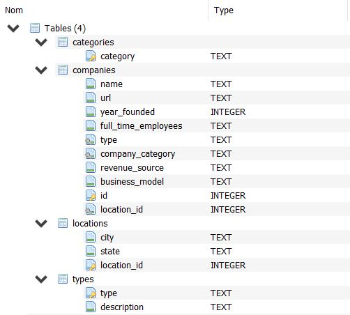

# Question 1.4 - Requêtes sur la nouvelle base de données

## Compagnies fondées entre 1999 et 2001

```r
# Connexion à la base de données

mydb <- dbConnect(RSQLite::SQLite(),
'db_persistence.sqlite')

sql_year <- dbGetQuery(mydb,
                       paste('SELECT name, url',
                             'FROM companies',
                             'WHERE year_founded',
                             'BETWEEN 1999 AND 2001',
                             'ORDER BY name'))

# Déconnexion de la base de données

dbDisconnect(mydb)
```

| name | url |
| --- | --- |
| Accela | http://www.accela.com |
| Adaptive | http://www.adaptive.com |
| Alarm.com | www.alarm.com |
| Aureus Sciences (*Now part of Elsevier) | http://www.aureus-sciences.com |
| Azavea | azavea.com |
| Biovia | http://accelrys.com |
| Caspio | http://www.caspio.com/ |
| Compliance and Risks | http://www.complianceandrisks.com |
| Connotate | http://www.connotate.com |
| Equilar | http://www.equilar.com/ |
| Fastcase | fastcase.com |
| Graematter, Inc. | www.graematter.com |
| Granicus | http://www.granicus.com |
| IVES Group Inc | http://auditanalytics.com/ |
| IW Financial | http://info.iwfinancial.com |
| Impaq International | http://www.impaqint.com |
| InfoCommerce Group | http://infocommercegroup.com |
| InnoCentive | http://www.innocentive.com |
| Innovest Systems | http://www.innovestsystems.com |
| Level One Technologies | http://www.levelonetechnologies.com |
| Maponics | http://www.maponics.com/ |
| Onvia | http://www.onvia.com |
| OpenPlans | http://openplans.org |
| Overture Technologies | http://www.overturecorp.com/ |
| PIXIA Corp | www.pixia.com |
| PayScale, Inc. | http://www.payscale.com |
| PowerAdvocate | http://www.poweradvocate.com/index.html |
| Quid | http://quid.com |
| Stamen Design | http://stamen.com/ |
| Telenav | http://www.telenav.com/ |
| TopCoder | http://www.topcoder.com/ |
| Trintech | http://www.trintech.com/ |
| Weather Decision Technologies | http://www.wdtinc.com/ |
| Whitby Group | http://www.whitbygroup.com |
| Xignite | http://www.xignite.com/ |
| Zebu Compliance Solutions | www.zebucompliance.com |

## Compagnies présentes en Oregon

```r
# Connexion à la base de données

mydb <- dbConnect(RSQLite::SQLite(),
'db_persistence.sqlite')

sql_oregon <- dbGetQuery(mydb,
                         paste('SELECT name, url, city, state, year_founded',
                               'FROM companies',
                               'LEFT JOIN locations ON companies.location_id == locations.location_id',
                               'WHERE state == "OR"'))


# Déconnexion de la base de données

dbDisconnect(mydb)
```

Suite à cette requête, on constate qu’il y a **2** compagnies qui sont présentes en Oregon dont on peut voir la liste dans le tableau 13.

**Tableau 13 - Liste des compagnies présentes en Oregon**

| name | url | city | state | year_founded |
| --- | --- | --- | --- | --- |
| FlightStats | http://www.flightstats.com/ | Portland | OR | 2005 |
| Urban Airship | http://urbanairship.com/ | NA | OR | 2009 |